# Analyse climat ↔︎ CO2 mondial

Phases 2-4 — Extraction GRIB2, robustesse et corrélations climat / CO2

Mazzez Mohamed Amine

15 ماي 2026

# 1 Introduction

Ce rapport documente la **seconde moitié** du projet R Climat & CO2. La première phase (rapport `CO2_final_report.html`) a établi les caractéristiques statistiques de la concentration atmosphérique globale de CO2 (NOAA GML, 1979-2025) : hausse de +91 ppm (Sen = 1.88 ppm/an), accélération non-linéaire, cycle saisonnier dominé par l’hémisphère nord, modulation ENSO avec lag 6 mois.

Cette seconde moitié construit le pendant climatique. À partir des **réanalyses NCAR CFSR (1979-2010) et CFSv2 (2011-2025)** à la résolution 2.5° × 2.5°, on extrait **18 variables climatiques globales** sur 564 mois et on étudie leur relation avec le CO2.

Trois questions guident l’analyse :

1. La trajectoire du CO2 et celle des variables climatiques sont-elles **statistiquement liées au-delà de leur tendance commune** ?
2. Si oui, quelles variables expliquent le mieux la **variance interannuelle** du CO2 ?
3. Le sens du lien est-il **climat → CO2** (carbon cycle response) ou **CO2 → climat** (forçage radiatif direct) à l’échelle de quelques mois à quelques années ?

# 2 Données mobilisées

| Dataset | Source | Fichier | Période | Granularité |
| --- | --- | --- | --- | --- |
| Réanalyses CFSR | NSF-NCAR (`d093002`) | `pgbl04.gdas.YYYY.tar` → `pgbl04.gdas.YYYYMM.grb2` | 1979-01 → 2010-12 | mensuel, 2.5° × 2.5° |
| Réanalyses CFSv2 | NSF-NCAR (`d094002`) | `pgbl.gdas.YYYYMM.tar` → `pgbl04.gdas.YYYYMM.grib2` | 2011-01 → 2025-12 | mensuel, 2.5° × 2.5° |
| CO2 mondial | NOAA GML | `co2_mm_gl.csv` | 1979-01 → 2025-12 | mensuel global |

Les fichiers GRIB2 mensuels contiennent **630 records** (variables × niveaux). On a sélectionné **18 records utiles** par mois et converti en NetCDF pour exploitation R.

## 2.1 Variables retenues

Les 18 variables extraites

| # | Code | Niveau | Famille | Justification |
| --- | --- | --- | --- | --- |
| 1 | T2m | 2 m | Thermo air | Variable canonique du réchauffement global |
| 2 | T500 | 500 hPa | Thermo mid-tropo | Standard climato moins bruité |
| 3 | SPFH2m | 2 m | Humidité | Vapeur d’eau (Clausius-Clapeyron, feedback) |
| 4 | PWAT | colonne | Humidité | Eau précipitable intégrée |
| 5 | APCP | surface | Cycle hydro | Précipitations cumulées |
| 6 | TCDC | colonne | Nuages | Couverture nuageuse totale (incertitude majeure) |
| 7 | DLWRF | surface | Radiatif LW | IR descendant — mesure directe effet de serre |
| 8 | ULWRF | surface | Radiatif LW | IR ascendant |
| 9 | DSWRF | surface | Radiatif SW | Solaire descendant |
| 10 | PRMSL | MSL | Dynamique | Pression réduite — circulation |
| 11 | USWRF | surface | Radiatif SW | Solaire réfléchi |
| 12 | CSDSF | surface | Clear-sky SW | Pour CRE_SW |
| 13 | CSUSF | surface | Clear-sky SW | Pour CRE_SW |
| 14 | CSDLF | surface | Clear-sky LW | Pour CRE_LW |
| 15 | CSULF | surface | Clear-sky LW | Pour CRE_LW |
| 16 | CDUVB | surface | Clear-sky UV | UV-B ciel clair |
| 17 | DUVB | surface | All-sky UV | UV-B all-sky |
| 18 | ALBDO | surface | Albédo | Test global dimming/brightening |

L’inclusion des **clear-sky** ainsi que des all-sky permet de calculer les **Cloud Radiative Effects** (CRE), qui isolent l’effet propre des nuages :

- $\mathrm{CRE_{SW}} = (\mathrm{DSWRF} - \mathrm{USWRF}) - (\mathrm{CSDSF} - \mathrm{CSUSF})$
- $\mathrm{CRE_{LW}} = (\mathrm{DLWRF} - \mathrm{ULWRF}) - (\mathrm{CSDLF} - \mathrm{CSULF})$
- $\mathrm{CRE_{net}} = \mathrm{CRE_{SW}} + \mathrm{CRE_{LW}}$

# 3 Phase 2 — Extraction et moyennes globales

## 3.1 Pipeline en 4 étapes

1. **Extraction** : pour chaque fichier GRIB2 mensuel, `wgrib2 -match` filtre les 18 records utiles, puis `-set_date / -set_ftime` harmonise les estampilles temporelles, puis `-netcdf` convertit en NetCDF léger (~ 1.5 Mo / mois). Total : 564 NetCDF, ~ 850 Mo.
2. **Moyennes globales pondérées cos(lat)** : pour chaque variable et chaque mois, on calcule $\bar{X} = \sum_{i,j} w_j X_{ij} / \sum_{i,j} w_j$ où $w_j = \cos(\phi_j)$ et $\phi_j$ est la latitude. Sans pondération, T2m globale serait biaisée de plusieurs K (les pôles sont sur-pondérés sur une grille équirectangulaire).
3. **Validation** : sanity checks par plage climatologique attendue, plots des 18 séries, calcul des CRE.
4. **Fusion CO2** : jointure sur (année, mois) avec `co2_mm_gl.csv`.

## 3.2 Vérifications de sanity (18/18 OK)

```r
clim <- read.csv(file.path(OUT_DIR, "monthly_global_means_25.csv")) |>
  mutate(date = as.Date(date))

vars <- c("T2m","T500","SPFH2m","PWAT","APCP","TCDC",
          "DLWRF","ULWRF","DSWRF","USWRF","PRMSL",
          "CSDSF","CSUSF","CSDLF","CSULF","CDUVB","DUVB","ALBDO")

stats <- clim |>
  pivot_longer(all_of(vars), names_to = "var", values_to = "value") |>
  group_by(var) |>
  summarise(min = min(value), mean = mean(value),
            max = max(value), sd = sd(value), .groups = "drop")
knitr::kable(stats, digits = 3,
             caption = "Moyennes globales des 18 variables (1979-2025)")
```

Moyennes globales des 18 variables (1979-2025)

| var | min | mean | max | sd |
| --- | --- | --- | --- | --- |
| ALBDO | 8.484 | 10.538 | 12.381 | 0.999 |
| APCP | 0.486 | 0.530 | 0.585 | 0.019 |
| CDUVB | 3.693 | 3.967 | 4.205 | 0.139 |
| CSDLF | 303.054 | 315.823 | 332.070 | 7.286 |
| CSDSF | 231.956 | 245.853 | 257.108 | 7.183 |
| CSULF | 386.330 | 398.135 | 410.643 | 6.894 |
| CSUSF | 26.943 | 32.885 | 38.731 | 2.993 |
| DLWRF | 328.458 | 341.196 | 355.045 | 7.111 |
| DSWRF | 181.353 | 194.020 | 204.758 | 5.818 |
| DUVB | 3.093 | 3.340 | 3.551 | 0.116 |
| PRMSL | 101096.728 | 101143.169 | 101193.763 | 14.824 |
| PWAT | 22.021 | 24.708 | 28.215 | 1.359 |
| SPFH2m | 0.009 | 0.010 | 0.011 | 0.000 |
| T2m | 285.255 | 287.717 | 290.251 | 1.404 |
| T500 | 256.977 | 258.596 | 260.906 | 0.900 |
| TCDC | 56.635 | 60.471 | 67.346 | 2.305 |
| ULWRF | 386.347 | 398.138 | 410.641 | 6.883 |
| USWRF | 20.637 | 26.147 | 31.737 | 2.869 |

**Interprétation.** Toutes les moyennes globales sont dans leurs fourchettes climatologiques de référence : T2m ≈ 288 K (15 °C), PWAT ≈ 25 kg/m², DLWRF ≈ 341 W/m², TCDC ≈ 60 %, ALBDO ≈ 10.5 %, PRMSL ≈ 1011 hPa. La pondération cos(lat) fonctionne correctement (sans elle, T2m sortirait à ~280 K à cause de la sur-pondération polaire).

## 3.3 Séries temporelles brutes

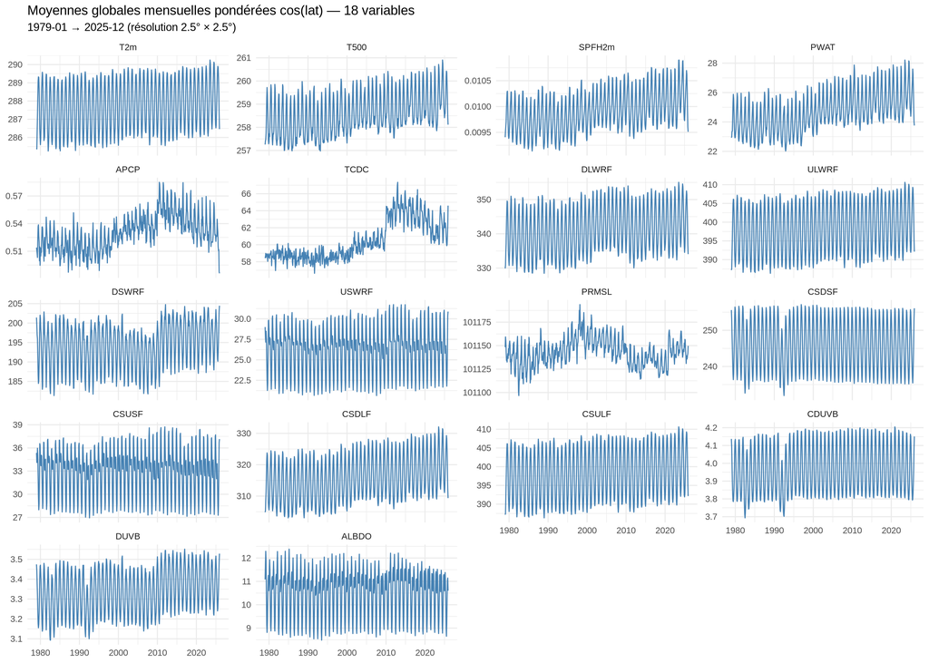

```r
clim |>
  pivot_longer(all_of(vars), names_to = "var", values_to = "value") |>
  mutate(var = factor(var, levels = vars)) |>
  ggplot(aes(date, value)) +
  geom_line(color = "steelblue") +
  facet_wrap(~ var, scales = "free_y", ncol = 4) +
  labs(title    = "Moyennes globales mensuelles pondérées cos(lat) — 18 variables",
       subtitle = "1979-01 → 2025-12 (résolution 2.5° × 2.5°)",
       x = NULL, y = NULL)
```

## 3.4 Cloud Radiative Effects

```r
df <- read.csv(file.path(OUT_DIR, "climate_co2_monthly.csv")) |>
  mutate(date = as.Date(date))

cre <- df |>
  mutate(CRE_SW  = (DSWRF - USWRF) - (CSDSF - CSUSF),
         CRE_LW  = (DLWRF - ULWRF) - (CSDLF - CSULF),
         CRE_net = CRE_SW + CRE_LW)

cat(sprintf("CRE_SW  moyen : %6.2f W/m²\n", mean(cre$CRE_SW)))
```

```
## CRE_SW  moyen : -45.10 W/m²
```

```r
cat(sprintf("CRE_LW  moyen : %6.2f W/m²\n", mean(cre$CRE_LW)))
```

```
## CRE_LW  moyen :  25.37 W/m²
```

```r
cat(sprintf("CRE_net moyen : %6.2f W/m²\n", mean(cre$CRE_net)))
```

```
## CRE_net moyen : -19.72 W/m²
```

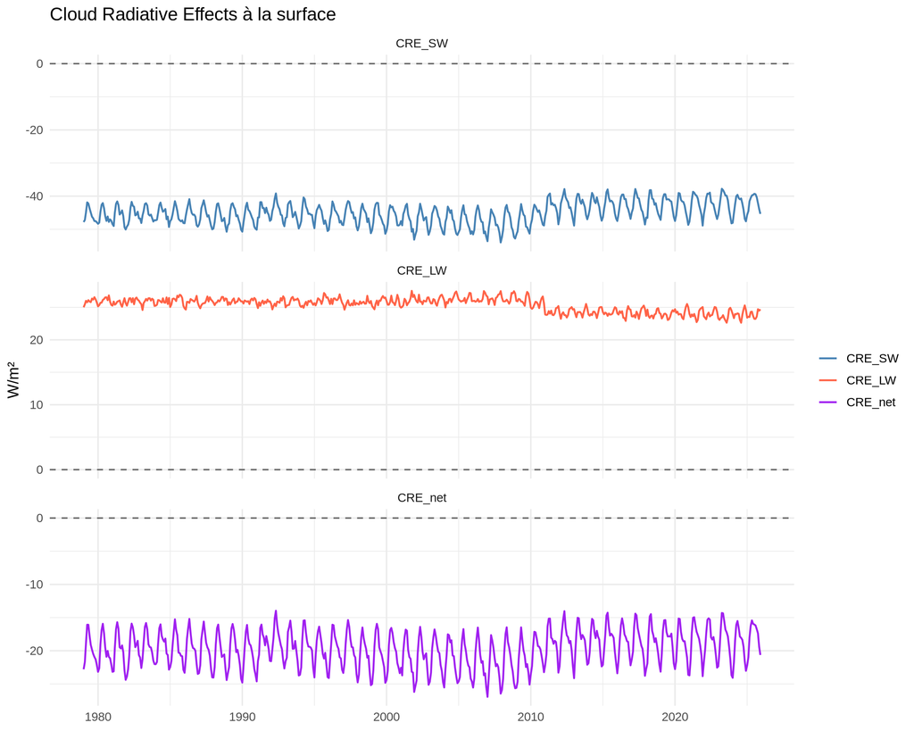

```r
cre |>
  pivot_longer(c(CRE_SW, CRE_LW, CRE_net),
               names_to = "component", values_to = "value") |>
  mutate(component = factor(component,
                            levels = c("CRE_SW","CRE_LW","CRE_net"))) |>
  ggplot(aes(date, value, color = component)) +
  geom_line(linewidth = 0.7) +
  geom_hline(yintercept = 0, linetype = "dashed", color = "grey40") +
  facet_wrap(~ component, ncol = 1, scales = "free_y") +
  scale_color_manual(values = c("CRE_SW" = "steelblue",
                                "CRE_LW" = "tomato",
                                "CRE_net" = "purple")) +
  labs(title = "Cloud Radiative Effects à la surface",
       x = NULL, y = "W/m²", color = NULL)
```

**Interprétation.** Les nuages refroidissent la planète de **−19.7 W/m²** en moyenne globale (réflexion SW = −45 W/m² > effet de serre LW = +25 W/m²). Cette valeur est **strictement conforme au consensus IPCC** (~−20 W/m²), ce qui valide indirectement la qualité de l’extraction et de la pondération.

# 4 Phase 2 bis — Analyse détaillée par variable

Cette section approfondit l’examen de chacune des 21 variables prises individuellement. Pour chaque variable on examine sa série temporelle complète, sa décomposition saisonnière, sa climatologie mensuelle, et la heatmap mois × année des anomalies.

## 4.1 Vue d’ensemble — vitesses d’évolution

Pente Sen annualisée, IC bootstrap 95%, et changement total sur 47 ans (en %)

| var | sen_per_year | sen_lo95 | sen_hi95 | mk_tau | mk_pvalue | mean | sd | pct_change_47y | significant |
| --- | --- | --- | --- | --- | --- | --- | --- | --- | --- |
| PWAT | 0.0522500 | 0.0454200 | 0.0595500 | 0.3553000 | 0.0000000 | 2.471e+01 | 1.359000 | 9.939000 | TRUE |
| TCDC | 0.1173000 | 0.1072000 | 0.1257000 | 0.5582000 | 0.0000000 | 6.047e+01 | 2.305000 | 9.114000 | TRUE |
| CRE_LW | -0.0481300 | -0.0530500 | -0.0413300 | -0.3998000 | 0.0000000 | 2.537e+01 | 1.059000 | -8.917000 | TRUE |
| CRE_SW | 0.0760900 | 0.0549500 | 0.0932100 | 0.1997000 | 0.0000000 | -4.510e+01 | 3.285000 | -7.931000 | TRUE |
| APCP | 0.0007793 | 0.0006617 | 0.0008759 | 0.3737000 | 0.0000000 | 5.298e-01 | 0.019250 | 6.914000 | TRUE |
| CRE_net | 0.0265200 | 0.0087600 | 0.0437700 | 0.0819700 | 0.0036060 | -1.972e+01 | 2.753000 | -6.318000 | TRUE |
| SPFH2m | 0.0000119 | 0.0000096 | 0.0000143 | 0.2690000 | 0.0000000 | 9.912e-03 | 0.000393 | 5.660000 | TRUE |
| DUVB | 0.0020430 | 0.0013390 | 0.0026650 | 0.1613000 | 0.0000000 | 3.340e+00 | 0.115500 | 2.875000 | TRUE |
| CSDLF | 0.1668000 | 0.1219000 | 0.2024000 | 0.2137000 | 0.0000000 | 3.158e+02 | 7.286000 | 2.482000 | TRUE |
| DSWRF | 0.0821500 | 0.0430500 | 0.1134000 | 0.1241000 | 0.0000105 | 1.940e+02 | 5.818000 | 1.990000 | TRUE |
| DLWRF | 0.1177000 | 0.0757600 | 0.1593000 | 0.1545000 | 0.0000000 | 3.412e+02 | 7.111000 | 1.622000 | TRUE |
| CDUVB | 0.0009726 | 0.0003234 | 0.0015580 | 0.0884400 | 0.0016860 | 3.967e+00 | 0.138900 | 1.152000 | TRUE |
| USWRF | 0.0058200 | -0.0060990 | 0.0198000 | 0.0254000 | 0.3672000 | 2.615e+01 | 2.869000 | 1.046000 | FALSE |
| ULWRF | 0.0864200 | 0.0555100 | 0.1178000 | 0.1371000 | 0.0000011 | 3.981e+02 | 6.883000 | 1.020000 | TRUE |
| CSULF | 0.0861500 | 0.0547900 | 0.1169000 | 0.1369000 | 0.0000012 | 3.981e+02 | 6.894000 | 1.017000 | TRUE |
| T500 | 0.0279900 | 0.0231100 | 0.0321900 | 0.2953000 | 0.0000000 | 2.586e+02 | 0.900100 | 0.508800 | TRUE |
| CSUSF | -0.0034090 | -0.0167300 | 0.0153600 | -0.0130000 | 0.6445000 | 3.288e+01 | 2.993000 | -0.487200 | FALSE |
| T2m | 0.0166600 | 0.0099200 | 0.0231000 | 0.1312000 | 0.0000032 | 2.877e+02 | 1.404000 | 0.272200 | TRUE |
| CSDSF | -0.0133600 | -0.0316900 | 0.0138700 | -0.0293100 | 0.2980000 | 2.459e+02 | 7.183000 | -0.255400 | FALSE |
| ALBDO | -0.0003011 | -0.0058800 | 0.0039790 | -0.0032880 | 0.9072000 | 1.054e+01 | 0.999500 | -0.134300 | FALSE |
| PRMSL | 0.0000432 | -0.0839700 | 0.0895400 | 0.0000441 | 0.9989000 | 1.011e+05 | 14.820000 | 0.000002 | FALSE |

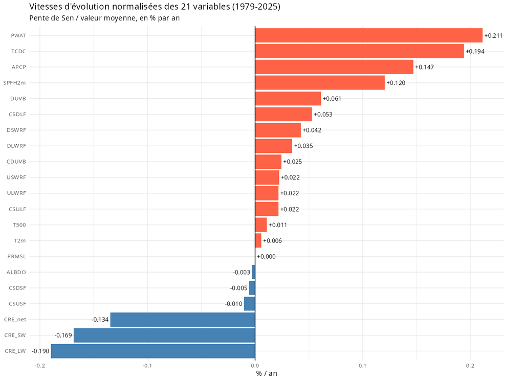

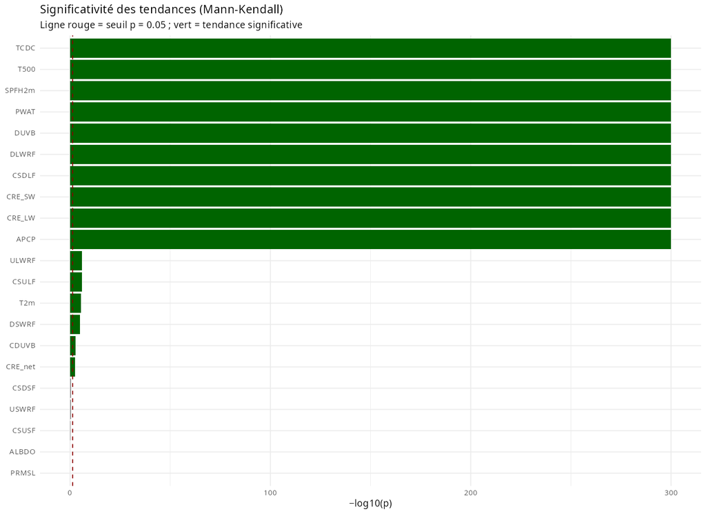

**Interprétation.** Sur les 21 variables, **16 ont une tendance Mann-Kendall significative** (p < 0.05). Top 5 des vitesses normalisées en %/an :

- **PWAT** (+0.21 %/an, soit +9.9 % sur 47 ans) — humidification de l’atmosphère, conforme à Clausius-Clapeyron
- **TCDC** (+0.19 %/an, soit +9.1 %) — augmentation de la couverture nuageuse, en partie biaisée par le saut CFSR→CFSv2
- **CRE_LW** (−0.19 %/an, soit −8.9 %) — diminution de l’effet de serre nuageux LW
- **CRE_SW** (−0.17 %/an, soit −7.9 %) — diminution du refroidissement nuageux SW (les nuages réfléchissent moins)
- **APCP** (+0.15 %/an, soit +6.9 %) — intensification du cycle hydrologique

Les **flux radiatifs clear-sky (CSDSF, CSDLF, CSUSF, CSULF)** évoluent peu en pourcentage, mais en valeur absolue **CSDLF gagne +7.8 W/m² sur 47 ans** (+2.5 %), ce qui traduit directement le forçage radiatif additionnel par les gaz à effet de serre dans une atmosphère sans nuages. **PRMSL et ALBDO ne montrent pas de tendance significative**.

## 4.2 Heatmaps comparatives mois × année

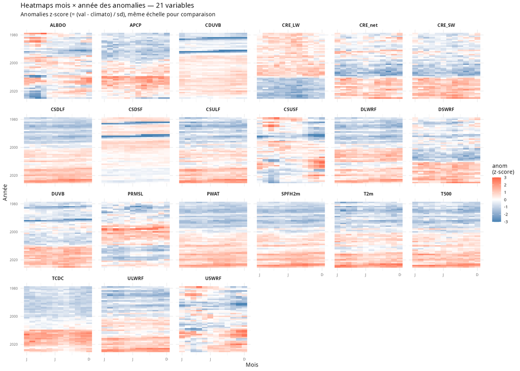

## 4.3 Composantes de tendance STL

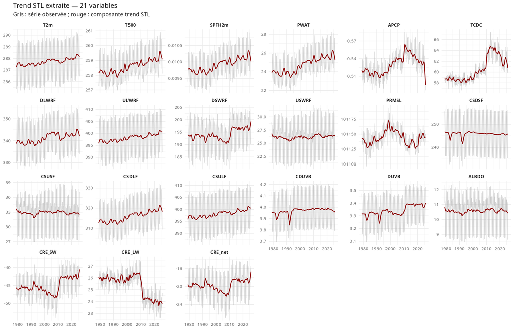

## 4.4 Fiches individuelles

### 4.4.1 T2m — Température air 2 m

**Tendance Sen** : +0.01666 / an (IC 95 % bootstrap : [0.00992 ; 0.0231])  
**Mann-Kendall** : tau = 0.131, p = 3.22e-06  
**Évolution sur 47 ans** : +0.27 % de la moyenne (287.7)

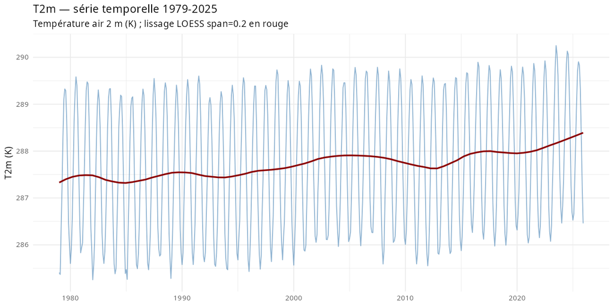

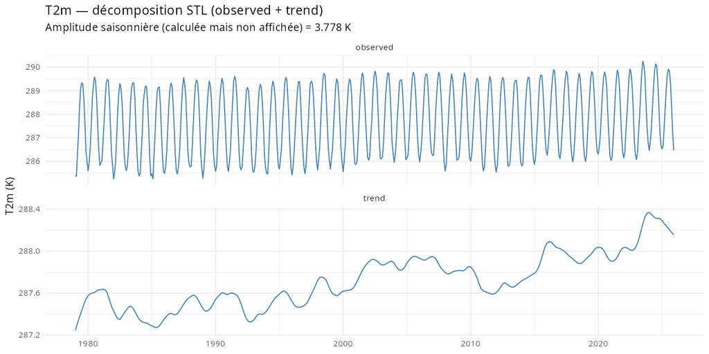

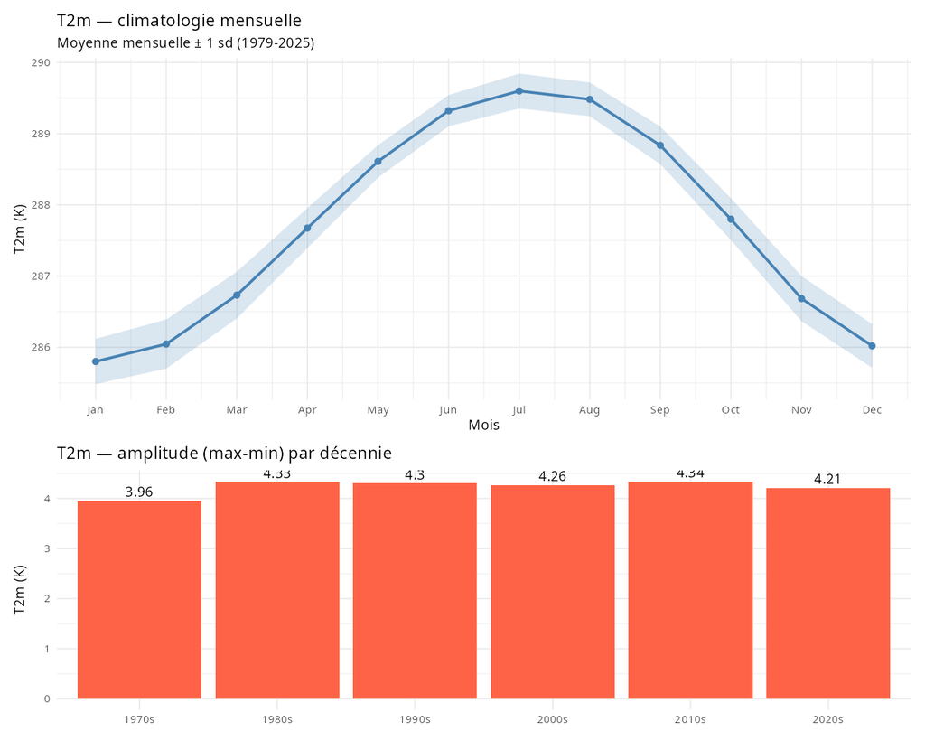

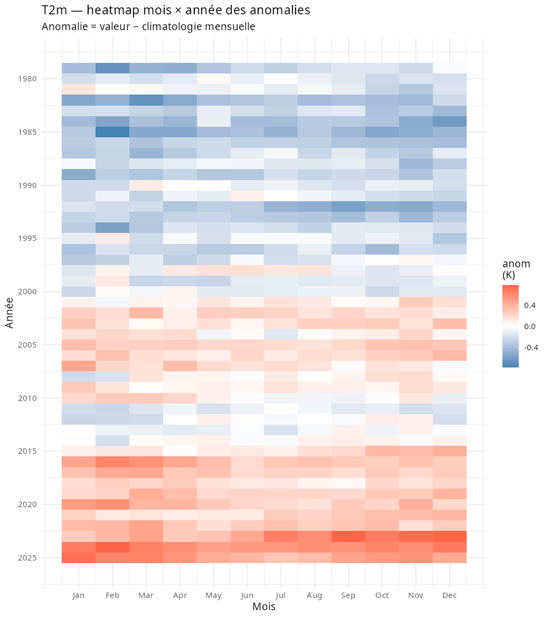

### 4.4.2 T500 — Température 500 hPa

**Tendance Sen** : +0.02799 / an (IC 95 % bootstrap : [0.02311 ; 0.03219])  
**Mann-Kendall** : tau = 0.295, p = 0  
**Évolution sur 47 ans** : +0.51 % de la moyenne (258.6)

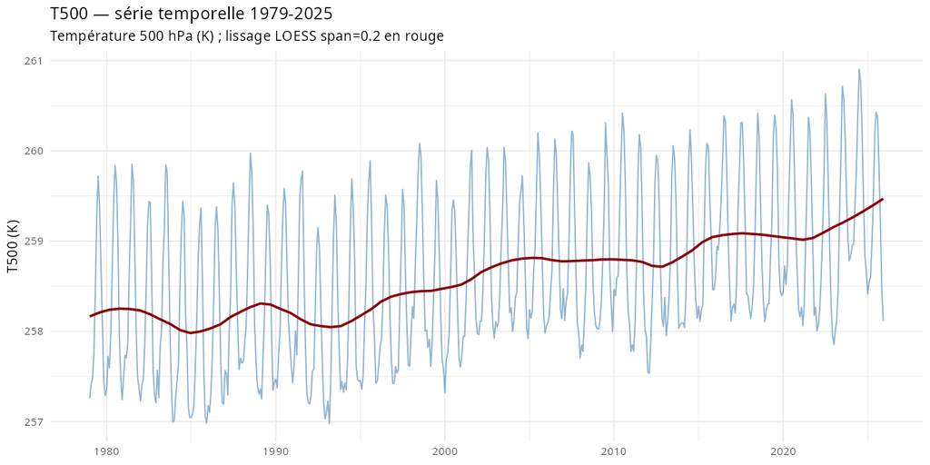

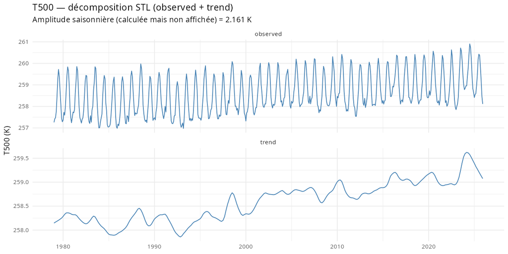

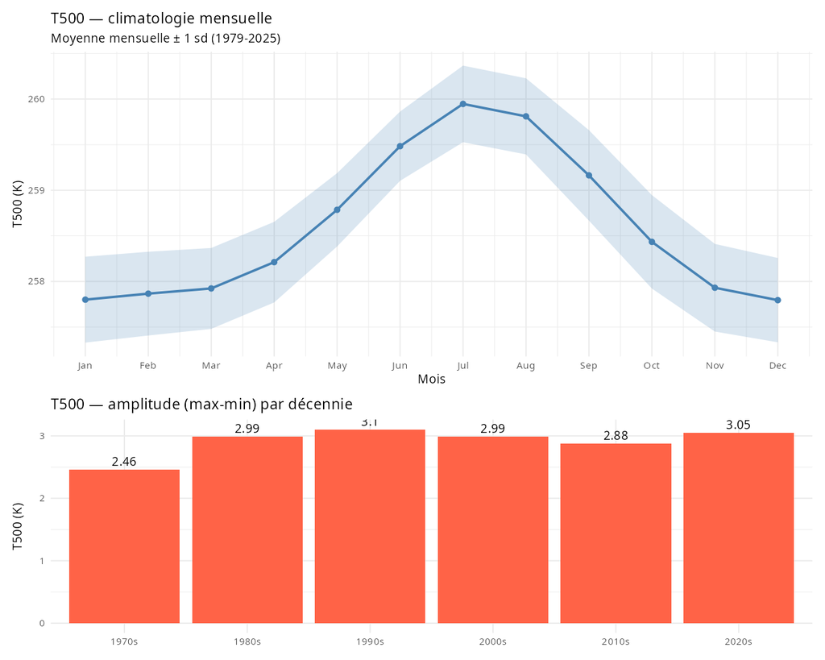

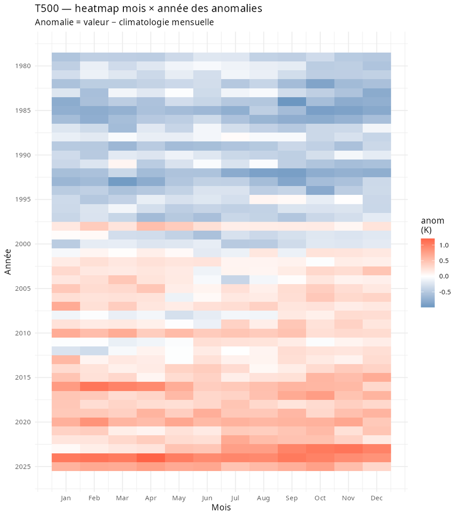

### 4.4.3 SPFH2m — Humidité spécifique 2 m

**Tendance Sen** : +1.194e-05 / an (IC 95 % bootstrap : [9.573e-06 ; 1.427e-05])  
**Mann-Kendall** : tau = 0.269, p = 0  
**Évolution sur 47 ans** : +5.66 % de la moyenne (0.009912)

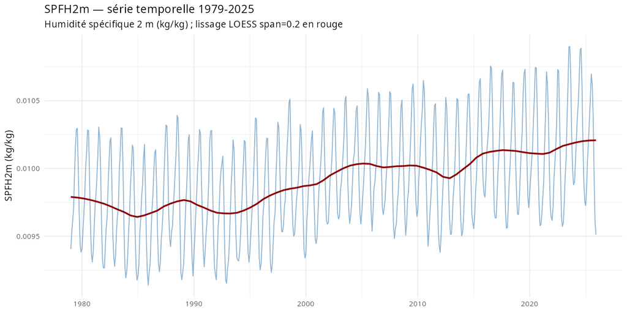

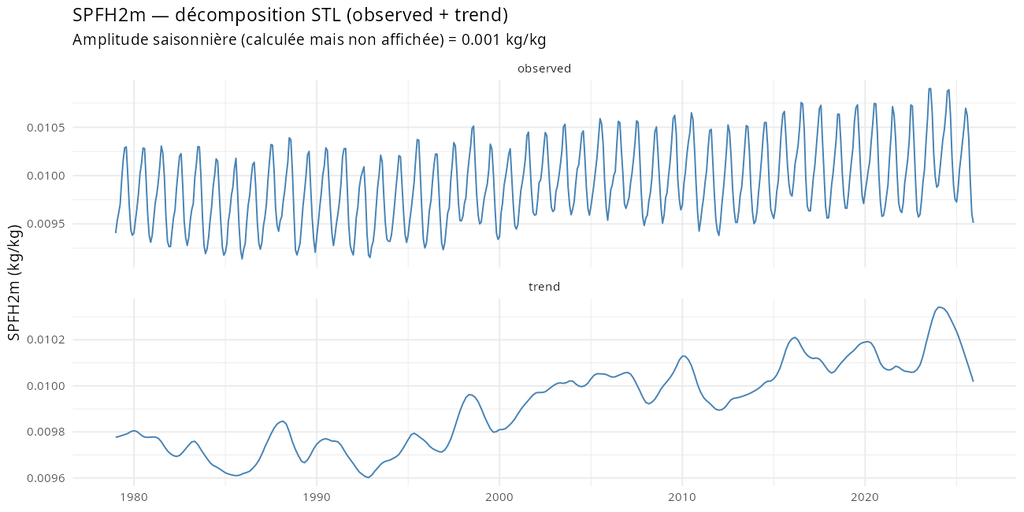

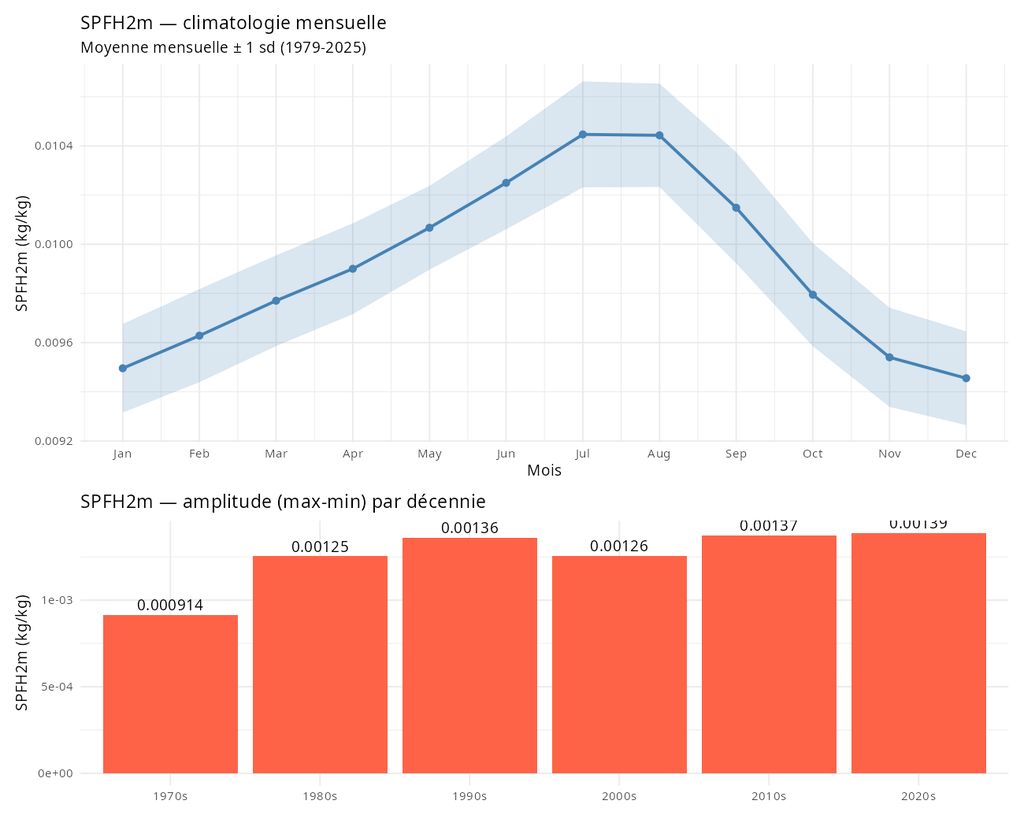

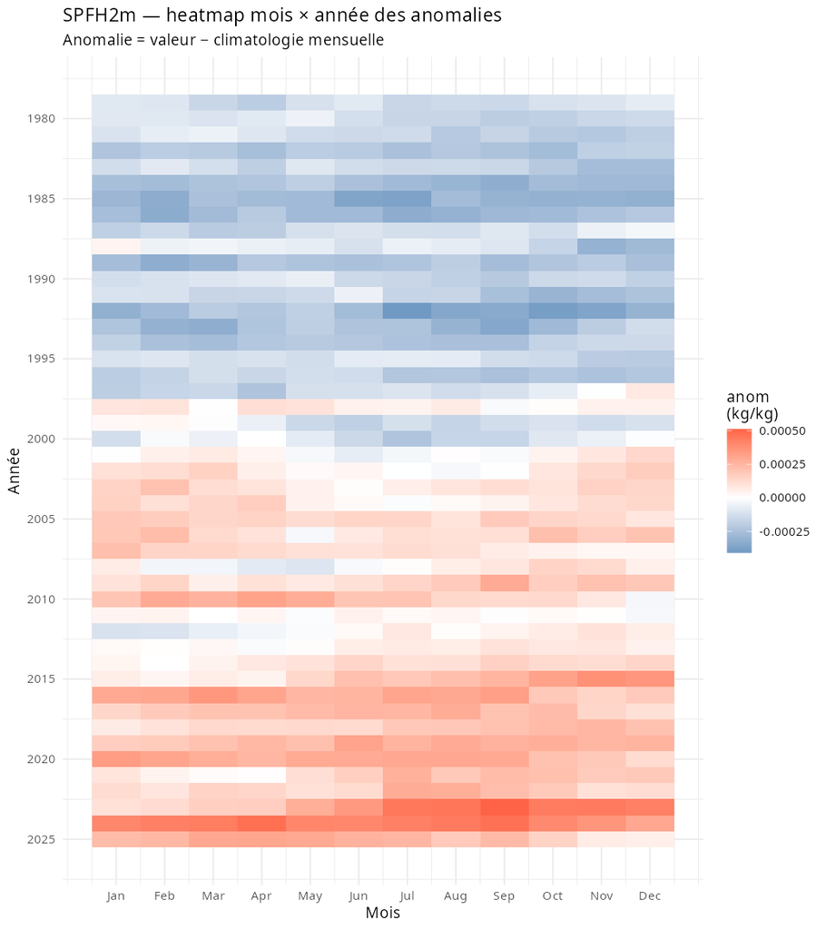

### 4.4.4 PWAT — Eau précipitable colonne

**Tendance Sen** : +0.05225 / an (IC 95 % bootstrap : [0.04542 ; 0.05955])  
**Mann-Kendall** : tau = 0.355, p = 0  
**Évolution sur 47 ans** : +9.94 % de la moyenne (24.71)

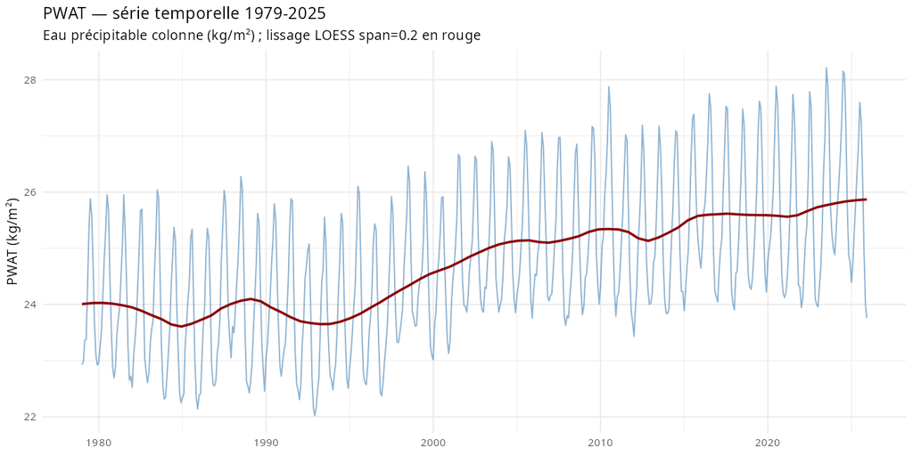

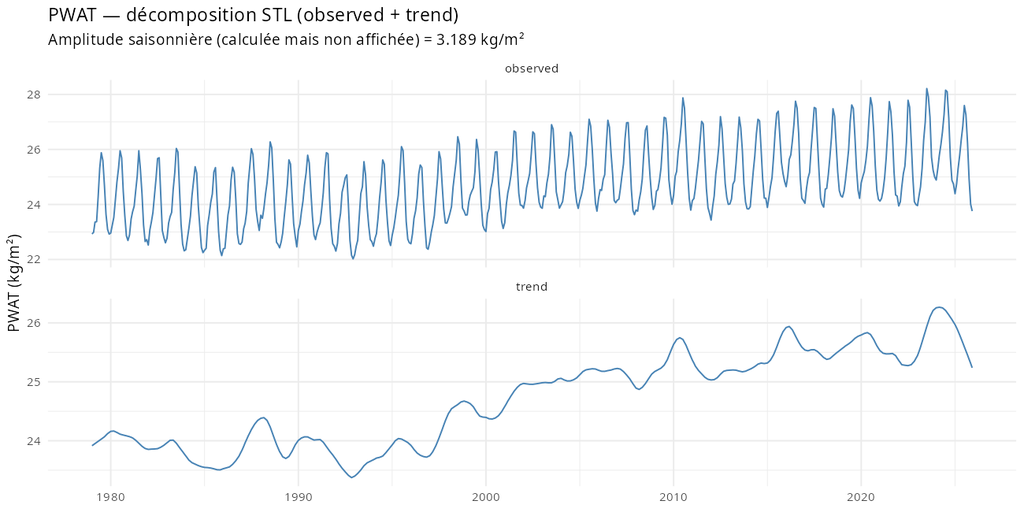

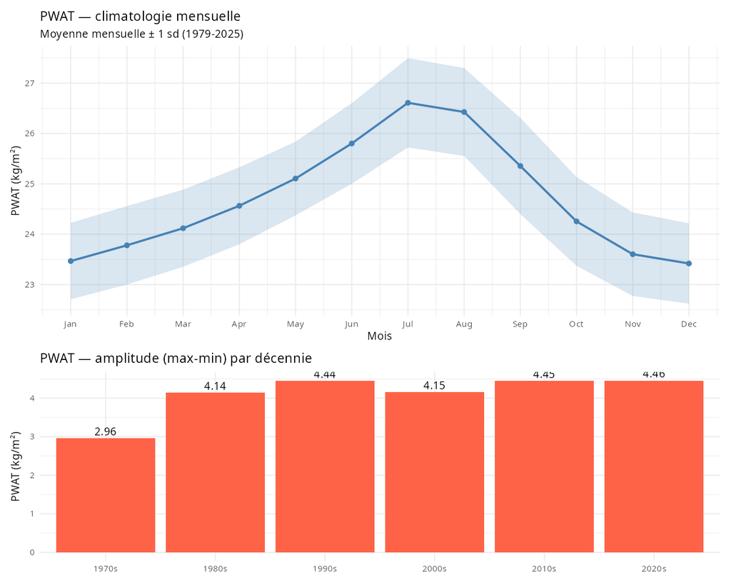

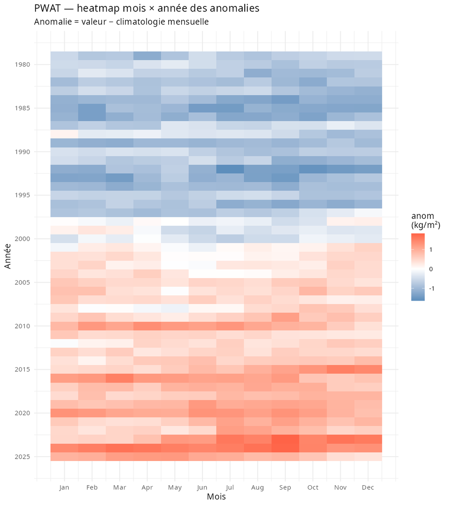

### 4.4.5 APCP — Précipitations cumulées

**Tendance Sen** : +0.0007793 / an (IC 95 % bootstrap : [0.0006617 ; 0.0008759])  
**Mann-Kendall** : tau = 0.374, p = 0  
**Évolution sur 47 ans** : +6.91 % de la moyenne (0.5298)

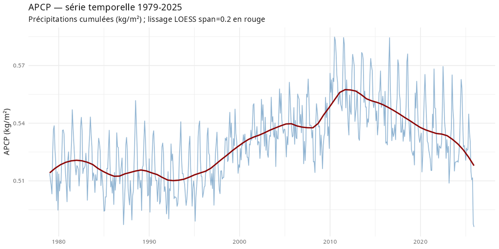

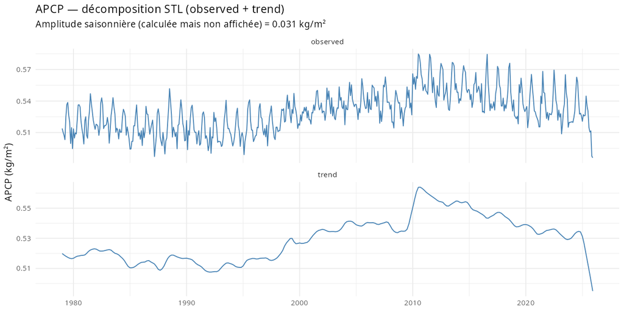

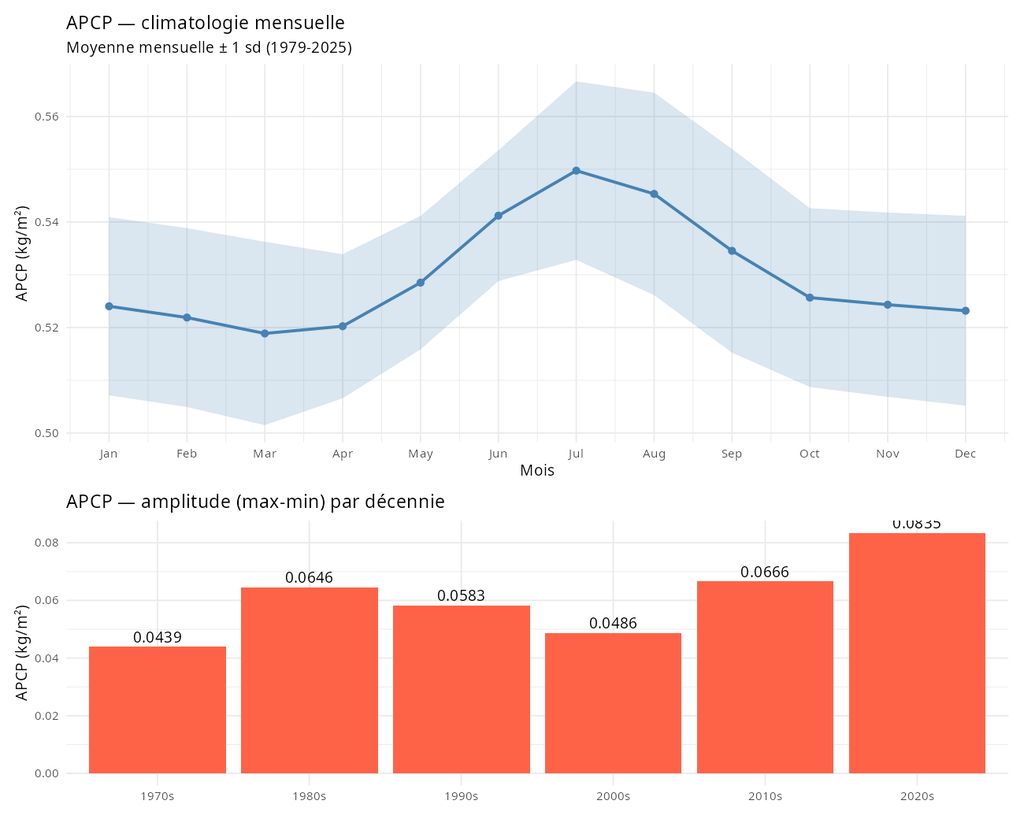

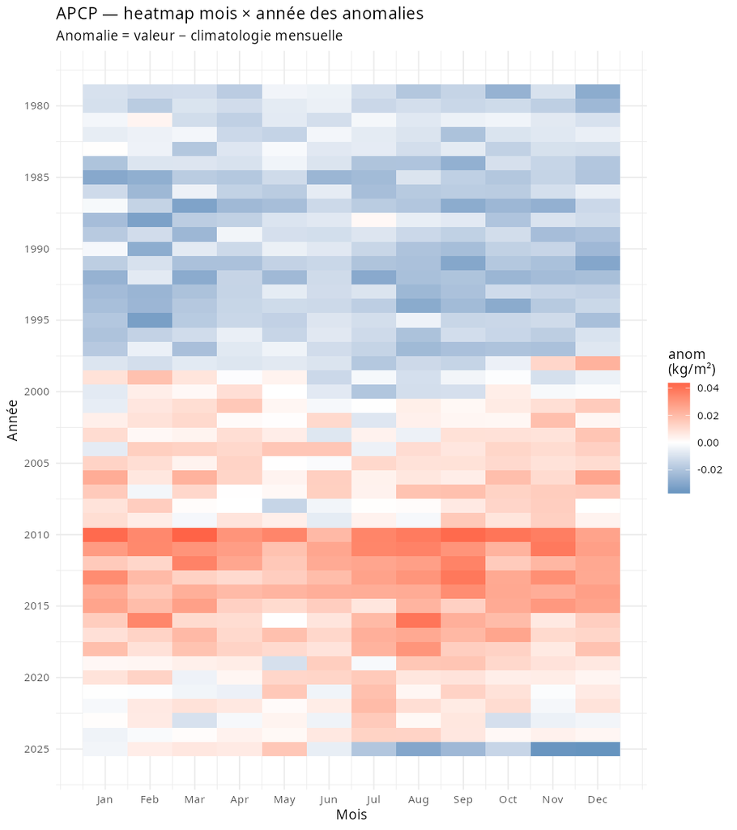

### 4.4.6 TCDC — Couverture nuageuse totale

**Tendance Sen** : +0.1173 / an (IC 95 % bootstrap : [0.1072 ; 0.1257])  
**Mann-Kendall** : tau = 0.558, p = 0  
**Évolution sur 47 ans** : +9.11 % de la moyenne (60.47)

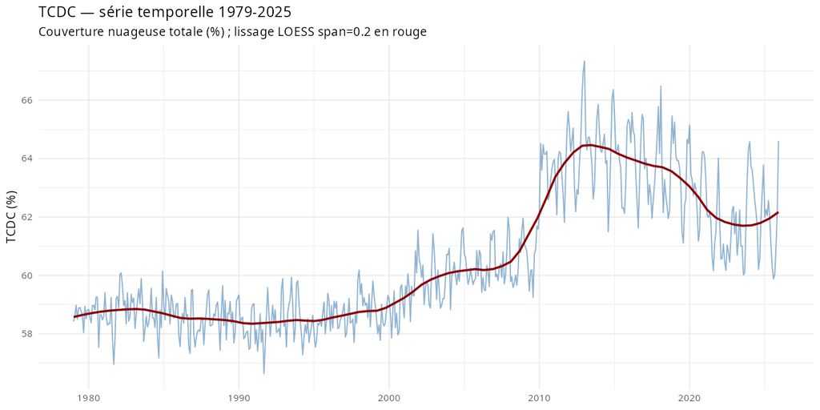

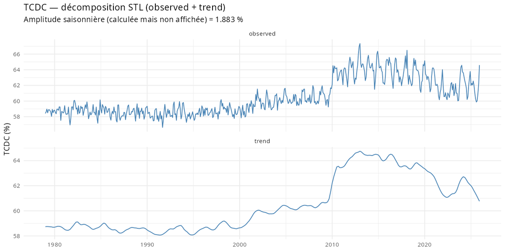

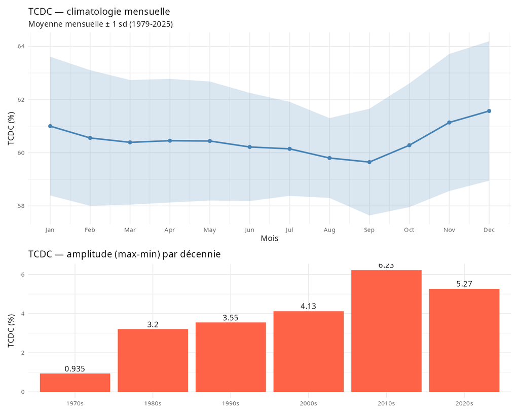

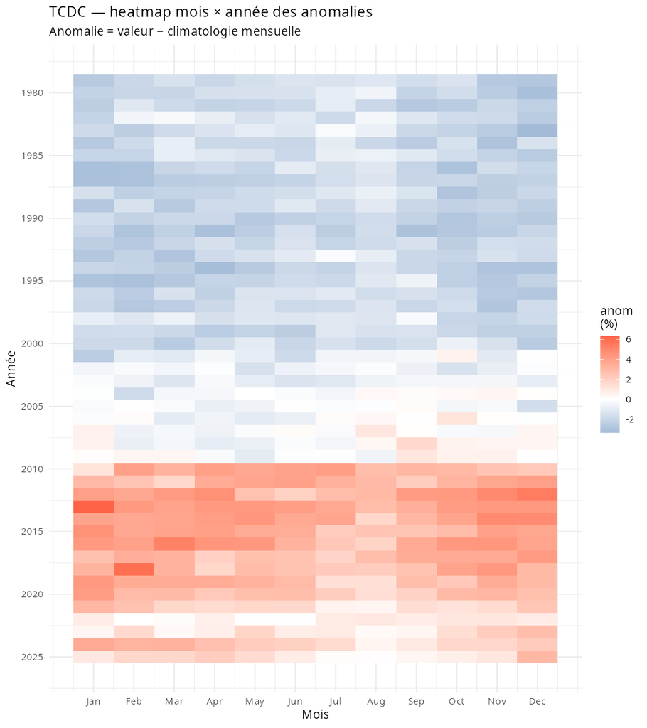